# Homework 2 - Jacob Igel

Last complied on March 02, 2023

# NOW WITH CORRECTIONS

1. A firm wishes to compare two banner ads. Banner A has 7,642 impressions and 85 clickthoughs. Banner B has 11,212 impressions and 122 click throughs. What are the click through rates for each ad?

CTR = clicks/impressions * 100

```r
ad1 = (85/7642) * 100

ad2 = (122/11212) * 100


ad1
```

```
## [1] 1.112274
```

```r
ad2
```

```
## [1] 1.08812
```

2. Continuing from 1: Is this difference statistically significant? Show the appropriate analysis using a corrected test of proportions (not the Wald test) and write your conclusions so anyone can understand the difference.

```r
prop.test(x=c(85,122), n=c(7642,11212))
```

```
##
##  2-sample test for equality of proportions with continuity correction
##
## data:  c(85, 122) out of c(7642, 11212)
## X-squared = 0.0072394, df = 1, p-value = 0.9322
## alternative hypothesis: two.sided
## 95 percent confidence interval:
##  -0.002904350  0.003387438
## sample estimates:
##     prop 1     prop 2
## 0.01112274 0.01088120
```

- The two versions of advertisements to customers and the proportions of people who responded is not significantly different between the two versions (95% CI Diff -0.002, 0.003).

# Class Corrections

**There is no significant difference in click rate between the two banner ads (95% CI Diff -0.002, 0.003).**

3. Suppose we wish to detect a difference of $0.094 (just under a dime) between two different online ads. Suppose the standard deviation of the response (sales) is $103.77 (the standard deviation will be large because most clicks do not produce sales so there are lots of 0’s in the data). For an A/B test how many observations do we need in each sample? Use a power of 0.8 and $\alpha=0.05$.

```r
power.t.test(n=NULL, delta=.094, sd=103.77, sig.level = 0.05, power = .8)
```

```
##
##      Two-sample t test power calculation
##
##               n = 19130469
##           delta = 0.094
##              sd = 103.77
##       sig.level = 0.05
##           power = 0.8
##     alternative = two.sided
##
## NOTE: n is number in *each* group
```

- For an appropriate A/B test, we would need 19,130,469 in each sample.
4. An A/B test results in 18 successes in 223 trials for version A and 26 successes in 287 trials for version B. What is the probability that the true proportion of version A is larger than the true proportion for version B. i.e. $P(p_a>p_b$)? Hint: Use the Beta-Binomial Model.

```r
# prop.test(x=c(18, 26), n=c(223, 287))
```

```r
# x<-seq(0,1,0.01)
# a=18+1
# b=223+1
# Afx<-dbeta(x, a, b)
# a1=26+1
# b1=287+1
# Bfx<-dbeta(x, a1, b1)
# plot(x, Afx, type="l")
# lines(x, Bfx, col="red")
```

# Class Corrections

```r
iter=100000
# Need to add the plus one because of math
a=18+1
b=205+1 # 223 - 18
a1=26+1
b1=261+1 # 287 - 26
count<-c()
for (i in 1:iter){
A<-rbeta(1, a, b)
B<-rbeta(1, a1, b1)
count[i]<-ifelse(A>B, 1, 0)


}
pdiff<-sum(count)/iter
pdiff
```

```
## [1] 0.35686
```

- Treatment: Different Logos
- Response: Average Spend
6. Read in the data from “booking.csv”. What is the average spend and standard deviation of spend for each version? I find it best to use the `stringsAsFactors=TRUE` argument in my `read.csv()` statement here.

```r
df <-
  read.csv("/Users/jacobigel/Desktop/School/ISA365-A/Datasets/booking.csv", stringsAsFactors = TRUE)

head(df)
```

```
##   visit_id user_spend variant
## 1    51763          0       A
## 2    52436          0       A
## 3    50203          0       A
## 4    56289          0       A
## 5    14265          0       A
## 6    16182          0       A
```

```r
library(tidyverse)
df %>% group_by(variant) %>% summarize("mean spend"=mean(user_spend), "std spend"=sd(user_spend),"count"= n())
```

```
## # A tibble: 2 × 4
##   variant `mean spend` `std spend` count
##   <fct>          <dbl>       <dbl> <int>
## 1 A               10.3        66.8  4889
## 2 B               13.2        72.6  5630
```

7. Visualize the data by each variant. Use any graph you feel shows the distribution of spend the best. Comment on your findings.

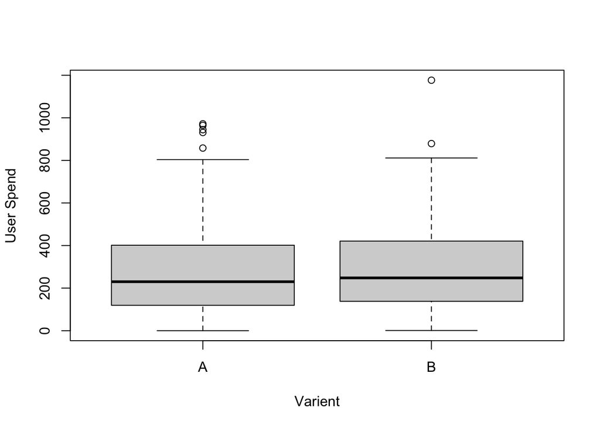

```r
library(tidyverse)
dff <- filter(df, user_spend >0)
# boxplot(df$user_spend~df$variant, xlab=("Varient"), ylab=("User Spend"), )
boxplot(user_spend~variant, xlab=("Varient"), ylab=("User Spend"), data = dff )
```

- While the majority of people did not spend anything for A or B, we can see the spread of B is more densely packed and has higher spending on average.
8. Find a 95% confidence interval for the difference in average spend for each variant. Use Welch’s test.

```r
t.test(df$user_spend~df$variant, var.equal = FALSE)
```

```
##
##  Welch Two Sample t-test
##
## data:  df$user_spend by df$variant
## t = -2.1428, df = 10482, p-value = 0.03215
## alternative hypothesis: true difference in means between group A and group B is not equal to 0
## 95 percent confidence interval:
##  -5.5778297 -0.2482742
## sample estimates:
## mean in group A mean in group B
##        10.31172        13.22478
```

9. Write a sentence giving a conclusion to your analysis based on the interval you found above.
- We can conclude that Group B produce more average user spend (95% CI Diff (-5.5778297 -0.2482742)); we also know that B user spend is higher than A since the mean is higher.

# Class Corrections

**The addition of the logos to the banner made a significant improvement in the user spend (95% CI Diff: ($0.25, $5.58)).**

- Treatment: The layout
- Response: Clicks
11. Read in the file “google_layout.csv”. And give a summary of the click through percentage by variant. I recommend using code for the `pivot_longer()` function from the Analyzing AB Tests Sample Means notes and the `group_by()` and `summarize()` functions. `everything()` is an argument that says we want to use all the columns in the data frame.

```r
df2 <- read.csv("/Users/jacobigel/Desktop/School/ISA365-A/Datasets/google_layout.csv", stringsAsFactors = TRUE)

head(df2)
```

```
##   list_layout tile_layout
## 1           0           0
## 2           0           0
## 3           0           0
## 4           0           0
## 5           0           0
## 6           0           0
```

```r
#
# df2_long <- pivot_longer(
#   df2,
#   everything(),
#   names_to="variant",
#   values_to="clicks"
#   ) %>%
#   group_by(Layout) %>%
#   summarize(Clicks)

# head(df2_long)



df2_long <- df2 %>% pivot_longer(
  cols = everything(),
  names_to="variant",
  values_to="clicks"
)

head(df2_long)
```

```
## # A tibble: 6 × 2
##   variant     clicks
##   <chr>        <int>
## 1 list_layout      0
## 2 tile_layout      0
## 3 list_layout      0
## 4 tile_layout      0
## 5 list_layout      0
## 6 tile_layout      0
```

```r
df2_long %>% group_by(variant, clicks) %>%  summarise(n = n()) %>%
  mutate(freq = n / sum(n))
```

```
## # A tibble: 4 × 4
## # Groups:   variant [2]
##   variant     clicks     n   freq
##   <chr>        <int> <int>  <dbl>
## 1 list_layout      0 19380 0.969
## 2 list_layout      1   620 0.031
## 3 tile_layout      0 19301 0.965
## 4 tile_layout      1   699 0.0350
```

12. Find a 95% confidence interval for the difference between each variant. Be sure to use the correction.

```r
# t.test(df2_long$Clicks ~ df2_long$Layout, var.equal = FALSE)

prop.test(x=c(620,699), n=c(19380+620, 19301+699))
```

```
##
##  2-sample test for equality of proportions with continuity correction
##
## data:  c(620, 699) out of c(19380 + 620, 19301 + 699)
## X-squared = 4.7699, df = 1, p-value = 0.02896
## alternative hypothesis: two.sided
## 95 percent confidence interval:
##  -0.0074997158 -0.0004002842
## sample estimates:
##  prop 1  prop 2
## 0.03100 0.03495
```

13. Give a sentence explaining that interval so that anyone can understand what the test results are showing. Give another sentence explaining your recommendation to Google.
- We can conclude that Tile Layout produce more average clicks (95% CI Diff ( -0.007, -0.0004)) than a list layout. I recommend that you use the tile layout rather than the list layout.

**The tile layout has an improved click rate compared to the list layout (95% CI Diff: 0.04%, 0.7%)**

14. For the Google layout with the highest clicks provide the percentage of clicks expected with a 95% confidence interval for that layout. Report those numbers in a sentence.

```r
table(df2_long)
```

```
##              clicks
## variant           0     1
##   list_layout 19380   620
##   tile_layout 19301   699
```

```r
prop.test(x=699, n=20000, correct = FALSE)
```

```
##
##  1-sample proportions test without continuity correction
##
## data:  699 out of 20000, null probability 0.5
## X-squared = 17302, df = 1, p-value < 2.2e-16
## alternative hypothesis: true p is not equal to 0.5
## 95 percent confidence interval:
##  0.03249273 0.03758589
## sample estimates:
##       p
## 0.03495
```

**We would expect a click rate of between 3.2% and 3.8% if the tile layout was implemented (95% CI).**